# Lesson3

noman

# Lesson3: R Markdown and Basic Functions

## Read the ‘datasets.xlsx’

#To install the package or library , consol:install.packages(‘readxl’), or Tools>Install Packages, or Packages in the file pane.

#To insert a command line: click C+. or `ctrl+alt+i`

```r
library(readxl)
df=read_excel('datasets.xlsx', sheet = 'wrangling', range = 'B7:N507')
head(df)
```

```
## # A tibble: 6 × 13
##     sr.   jan   feb   mar   apr   may   jun   jul   aug   sep   oct   nov   dec
##   <dbl> <dbl> <dbl> <dbl> <dbl> <dbl> <dbl> <dbl> <dbl> <dbl> <dbl> <dbl> <dbl>
## 1     1     0     1     1     0     0     0     0     0     0     0     0     0
## 2     2     0     1     1     1     0     0     0     0     0     0     0     0
## 3     3     1     0     1     0     1     0     0     0     0     0     0     0
## 4     4     0     0     1     1     0     1     0     0     1     0     0     0
## 5     5     1     0     0     0     0     0     0     0     0     1     0     0
## 6     6     0     1     0     0     0     0     0     0     0     0     0     0
```

```r
tail(df)
```

```
## # A tibble: 6 × 13
##     sr.   jan   feb   mar   apr   may   jun   jul   aug   sep   oct   nov   dec
##   <dbl> <dbl> <dbl> <dbl> <dbl> <dbl> <dbl> <dbl> <dbl> <dbl> <dbl> <dbl> <dbl>
## 1   495     0     1     0     1     0     0     1     0     0     0     0     0
## 2   496     0     1     1     0     0     0     0     0     0     0     0     0
## 3   497     1     0     1     1     1     0     0     0     0     0     0     0
## 4   498     0     0     0     1     1     0     1     0     0     0     0     0
## 5   499     1     0     0     0     0     0     0     0     0     0     0     1
## 6   500     0     0     0     1     0     0     0     0     0     0     0     0
```

#Calculating the column sum, excluding the colm no 1, only for 1 to 50 rows

```r
colSums(df[c(1:50),c(2:13)])
```

```
## jan feb mar apr may jun jul aug sep oct nov dec
##  13  22  20  20   8  15   7   4   3   2   2   3
```

```r
colSums(df[-1])
```

```
## jan feb mar apr may jun jul aug sep oct nov dec
## 143 177 196 179 112 109  90  45  41  40  38  21
```

Now give a name for this object and such as scarcity. Then express the frequency as percentage.

```r
scarcity=colSums(df[-1])*100/nrow(df)
scarcity
```

```
##  jan  feb  mar  apr  may  jun  jul  aug  sep  oct  nov  dec
## 28.6 35.4 39.2 35.8 22.4 21.8 18.0  9.0  8.2  8.0  7.6  4.2
```

#Visualize this month wise scarcity using ggplot [ggplot2 package]. First install ggplot2 package.

Scarcity is not a data frame but ggplot fumnction need data frame(with a few variables). convert scarcity to a data frame df_scarcity.

convert the row names to column named as `month` by using `dplyr`.

```r
library(tidyverse)
```

```r
#convert to data frame
df_scarcity=as.data.frame(scarcity)

#Transfer the row names to column as 'Month'
df_plot=rownames_to_column(df_scarcity, var= 'Month')

#Check the structure and dataframe
str(df_plot)
```

```
## 'data.frame':    12 obs. of  2 variables:
##  $ Month   : chr  "jan" "feb" "mar" "apr" ...
##  $ scarcity: num  28.6 35.4 39.2 35.8 22.4 21.8 18 9 8.2 8 ...
```

```r
df_plot
```

```
##    Month scarcity
## 1    jan     28.6
## 2    feb     35.4
## 3    mar     39.2
## 4    apr     35.8
## 5    may     22.4
## 6    jun     21.8
## 7    jul     18.0
## 8    aug      9.0
## 9    sep      8.2
## 10   oct      8.0
## 11   nov      7.6
## 12   dec      4.2
```

Now visualization. To set the order of the month names we need to reorder the month names using

```r
df_plot$Month= factor(df_plot$Month,
                      levels = c('jan', 'feb', 'mar','apr','may', 'jun', 'jul','aug','sep', 'oct', 'nov', 'dec'),
                      labels = c('Jan', 'Feb', 'Mar', 'Apr', 'May', 'Jun', 'Jul', 'Aug', 'Sep', 'Oct', 'Nov', 'Dec'))
```

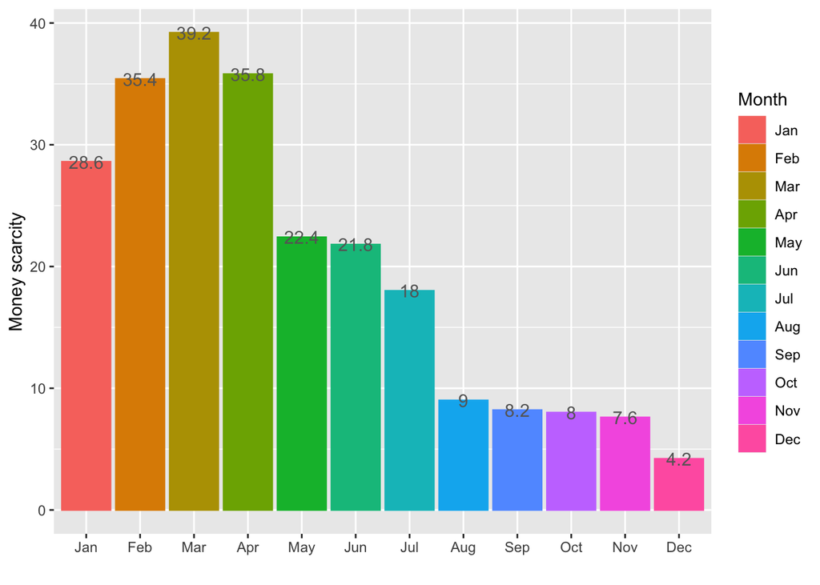

```r
ggplot(df_plot)+
  aes(x=Month, y=scarcity, color=Month, fill=Month)+
  geom_col()+
  labs(x='', y= 'Money scarcity')+
  geom_text(aes(label=scarcity), color='grey40')
```